# Predict Bike Sharing Demand with AutoGluon Template

### Download and explore dataset

### Go to the bike sharing demand competition and agree to the terms

```python
# Download the dataset, it will be in a .zip file so you'll need to unzip it as well.
!kaggle competitions download -c bike-sharing-demand
# If you already downloaded it you can use the -o command to overwrite the file
!unzip -o bike-sharing-demand.zip
```

```
bike-sharing-demand.zip: Skipping, found more recently modified local copy (use --force to force download)
Archive:  bike-sharing-demand.zip
  inflating: sampleSubmission.csv
  inflating: test.csv
  inflating: train.csv
```

```python
import pandas as pd
from autogluon.tabular import TabularPredictor
```

```python
# Create the train dataset in pandas by reading the csv
# Set the parsing of the datetime column so you can use some of the `dt` features in pandas later
train = pd.read_csv('train.csv', parse_dates=['datetime'])
train.head()
```

|  | datetime | season | holiday | workingday | weather | temp | atemp | humidity | windspeed | casual | registered | count |
| --- | --- | --- | --- | --- | --- | --- | --- | --- | --- | --- | --- | --- |
| 0 | 2011-01-01 00:00:00 | 1 | 0 | 0 | 1 | 9.84 | 14.395 | 81 | 0.0 | 3 | 13 | 16 |
| 1 | 2011-01-01 01:00:00 | 1 | 0 | 0 | 1 | 9.02 | 13.635 | 80 | 0.0 | 8 | 32 | 40 |
| 2 | 2011-01-01 02:00:00 | 1 | 0 | 0 | 1 | 9.02 | 13.635 | 80 | 0.0 | 5 | 27 | 32 |
| 3 | 2011-01-01 03:00:00 | 1 | 0 | 0 | 1 | 9.84 | 14.395 | 75 | 0.0 | 3 | 10 | 13 |
| 4 | 2011-01-01 04:00:00 | 1 | 0 | 0 | 1 | 9.84 | 14.395 | 75 | 0.0 | 0 | 1 | 1 |

```python
# Simple output of the train dataset to view some of the min/max/varition of the dataset features.
```

```python
train.describe()
```

|  | datetime | season | holiday | workingday | weather | temp | atemp | humidity | windspeed | casual | registered | count |
| --- | --- | --- | --- | --- | --- | --- | --- | --- | --- | --- | --- | --- |
| count | 10886 | 10886.000000 | 10886.000000 | 10886.000000 | 10886.000000 | 10886.00000 | 10886.000000 | 10886.000000 | 10886.000000 | 10886.000000 | 10886.000000 | 10886.000000 |
| mean | 2011-12-27 05:56:22.399411968 | 2.506614 | 0.028569 | 0.680875 | 1.418427 | 20.23086 | 23.655084 | 61.886460 | 12.799395 | 36.021955 | 155.552177 | 191.574132 |
| min | 2011-01-01 00:00:00 | 1.000000 | 0.000000 | 0.000000 | 1.000000 | 0.82000 | 0.760000 | 0.000000 | 0.000000 | 0.000000 | 0.000000 | 1.000000 |
| 25% | 2011-07-02 07:15:00 | 2.000000 | 0.000000 | 0.000000 | 1.000000 | 13.94000 | 16.665000 | 47.000000 | 7.001500 | 4.000000 | 36.000000 | 42.000000 |
| 50% | 2012-01-01 20:30:00 | 3.000000 | 0.000000 | 1.000000 | 1.000000 | 20.50000 | 24.240000 | 62.000000 | 12.998000 | 17.000000 | 118.000000 | 145.000000 |
| 75% | 2012-07-01 12:45:00 | 4.000000 | 0.000000 | 1.000000 | 2.000000 | 26.24000 | 31.060000 | 77.000000 | 16.997900 | 49.000000 | 222.000000 | 284.000000 |
| max | 2012-12-19 23:00:00 | 4.000000 | 1.000000 | 1.000000 | 4.000000 | 41.00000 | 45.455000 | 100.000000 | 56.996900 | 367.000000 | 886.000000 | 977.000000 |
| std | NaN | 1.116174 | 0.166599 | 0.466159 | 0.633839 | 7.79159 | 8.474601 | 19.245033 | 8.164537 | 49.960477 | 151.039033 | 181.144454 |

```python
# Create the test pandas dataframe in pandas by reading the csv, remember to parse the datetime!
test = pd.read_csv('test.csv', parse_dates=['datetime'])
test.head()
```

|  | datetime | season | holiday | workingday | weather | temp | atemp | humidity | windspeed |
| --- | --- | --- | --- | --- | --- | --- | --- | --- | --- |
| 0 | 2011-01-20 00:00:00 | 1 | 0 | 1 | 1 | 10.66 | 11.365 | 56 | 26.0027 |
| 1 | 2011-01-20 01:00:00 | 1 | 0 | 1 | 1 | 10.66 | 13.635 | 56 | 0.0000 |
| 2 | 2011-01-20 02:00:00 | 1 | 0 | 1 | 1 | 10.66 | 13.635 | 56 | 0.0000 |
| 3 | 2011-01-20 03:00:00 | 1 | 0 | 1 | 1 | 10.66 | 12.880 | 56 | 11.0014 |
| 4 | 2011-01-20 04:00:00 | 1 | 0 | 1 | 1 | 10.66 | 12.880 | 56 | 11.0014 |

```python
# Same thing as train and test dataset
submission = pd.read_csv('sampleSubmission.csv', parse_dates=['datetime'])
submission.head()
```

|  | datetime | count |
| --- | --- | --- |
| 0 | 2011-01-20 00:00:00 | 0 |
| 1 | 2011-01-20 01:00:00 | 0 |
| 2 | 2011-01-20 02:00:00 | 0 |
| 3 | 2011-01-20 03:00:00 | 0 |
| 4 | 2011-01-20 04:00:00 | 0 |

## Step 3: Train a model using AutoGluon’s Tabular Prediction

Requirements:

- We are prediting `count`, so it is the label we are setting.
- Ignore `casual` and `registered` columns as they are also not present in the test dataset.
- Use the `root_mean_squared_error` as the metric to use for evaluation.
- Set a time limit of 10 minutes (600 seconds).
- Use the preset `best_quality` to focus on creating the best model.

```python
# Ignore the 'casual' and 'registered' columns directly from the train DataFrame
train.drop(columns=['casual', 'registered'], inplace=True, errors='ignore')

predictor = TabularPredictor(label='count', eval_metric='root_mean_squared_error').fit(train_data=train, presets='best_quality', time_limit=600)
```

[output not shown]

[output cut: 416 more lines]

```
	-55.673	 = Validation score   (-root_mean_squared_error)
	7.6s	 = Training   runtime
	2.38s	 = Validation runtime
Fitting model: NeuralNetFastAI_r191_BAG_L2 ... Training model for up to 21.8s of the 21.72s of remaining time.
	Fitting 8 child models (S1F1 - S1F8) | Fitting with ParallelLocalFoldFittingStrategy (8 workers, per: cpus=1, gpus=0, memory=0.14%)
	-50.7199	 = Validation score   (-root_mean_squared_error)
	16.39s	 = Training   runtime
	0.11s	 = Validation runtime
Fitting model: WeightedEnsemble_L3 ... Training model for up to 360.0s of the 4.02s of remaining time.
	Ensemble Weights: {'NeuralNetFastAI_r191_BAG_L2': 0.494, 'RandomForestMSE_BAG_L2': 0.221, 'NeuralNetTorch_r79_BAG_L2': 0.195, 'NeuralNetTorch_BAG_L2': 0.078, 'ExtraTreesMSE_BAG_L2': 0.013}
	-49.7061	 = Validation score   (-root_mean_squared_error)
	0.52s	 = Training   runtime
	0.0s	 = Validation runtime
AutoGluon training complete, total runtime = 442.51s ... Best model: "WeightedEnsemble_L3"
TabularPredictor saved. To load, use: predictor = TabularPredictor.load("AutogluonModels/ag-20240403_115832")
```

### Review AutoGluon's training run with ranking of models that did the best.

```python
predictor.fit_summary()
```

```
*** Summary of fit() ***
Estimated performance of each model:
                          model   score_val              eval_metric  pred_time_val    fit_time  pred_time_val_marginal  fit_time_marginal  stack_level  can_infer  fit_order
0           WeightedEnsemble_L3  -49.706087  root_mean_squared_error      27.661577  342.923107                0.000239           0.516313            3       True         40
1   NeuralNetFastAI_r191_BAG_L2  -50.719856  root_mean_squared_error      26.899095  289.207590                0.109109          16.390034            2       True         39
2        NeuralNetFastAI_BAG_L2  -51.827377  root_mean_squared_error      26.861360  279.251075                0.071374           6.433519            2       True         32
3     NeuralNetTorch_r79_BAG_L2  -52.429678  root_mean_squared_error      26.890904  297.851314                0.100918          25.033758            2       True         37
4        RandomForestMSE_BAG_L2  -53.393357  root_mean_squared_error      27.078877  280.847092                0.288891           8.029536            2       True         29
5          ExtraTreesMSE_BAG_L2  -54.705913  root_mean_squared_error      27.078957  274.542347                0.288971           1.724791            2       True         31
6               LightGBM_BAG_L2  -54.881408  root_mean_squared_error      27.046369  274.937618                0.256383           2.120062            2       True         28
7                XGBoost_BAG_L2  -55.096155  root_mean_squared_error      26.846832  275.291074                0.056846           2.473518            2       True         33
8          LightGBMLarge_BAG_L2  -55.250951  root_mean_squared_error      27.144478  276.492319                0.354492           3.674763            2       True         35
9          LightGBM_r131_BAG_L2  -55.673026  root_mean_squared_error      29.174800  280.418176                2.384814           7.600620            2       True         38
10        NeuralNetTorch_BAG_L2  -55.758702  root_mean_squared_error      26.873450  291.228675                0.083464          18.411119            2       True         34
11              CatBoost_BAG_L2  -55.786306  root_mean_squared_error      26.805377  289.299111                0.015392          16.481555            2       True         30
```

[output cut: 40 more lines]

[output not shown]

[output cut: 441 more lines]

```
 25            1       True         11
 26            1       True         25
 27            1       True          6
 28            1       True         12
 29            1       True          4
 30            1       True          3
 31            1       True          9
 32            1       True         21
 33            1       True         15
 34            1       True         17
 35            1       True          8
 36            1       True         22
 37            1       True         18
 38            1       True         10
 39            1       True         13  }
```

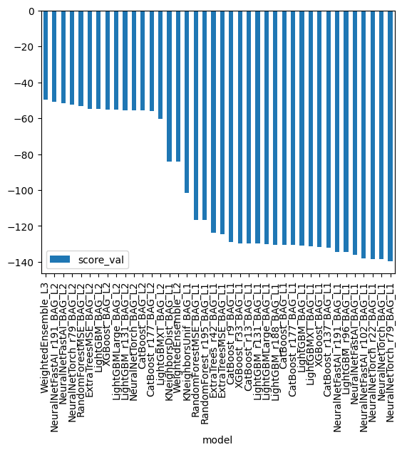

```python
predictor.leaderboard(silent=True).plot(kind="bar", x="model", y="score_val");
```

### Create predictions from test dataset

```python
predictions = predictor.predict(test)
predictions.head()
```

```
0    24.487661
1    38.138977
2    43.687904
3    47.090584
4    49.632339
Name: count, dtype: float32
```

#### NOTE: Kaggle will reject the submission if we don't set everything to be > 0.

```python
# Describe the `predictions` series to see if there are any negative values
predictions.describe()
```

```
count    6493.000000
mean       99.255714
std        89.670013
min         2.100537
25%        18.323490
50%        64.741013
75%       169.655518
max       355.480988
Name: count, dtype: float64
```

```python
# How many negative values do we have?
sum(predictions<0)
```

```
0
```

```python
# Set them to zero
# Not needed as there are no negative predictions
# predictions[predictions<0]=0
```

### Set predictions to submission dataframe, save, and submit

```python
submission["count"] = predictions
submission.to_csv("submission.csv", index=False)
```

```python
!kaggle competitions submit -c bike-sharing-demand -f submission.csv -m "first raw submission"
```

```
Successfully submitted to Bike Sharing Demand
```

#### View submission via the command line or in the web browser under the competition's page - `My Submissions`

```python
!kaggle competitions submissions -c bike-sharing-demand | tail -n +1 | head -n 6
```

[output not shown]

```python
1.8371
```

```
1.8371
```

## Step 4: Exploratory Data Analysis and Creating an additional feature

- Any additional feature will do, but a great suggestion would be to separate out the datetime into hour, day, or month parts.

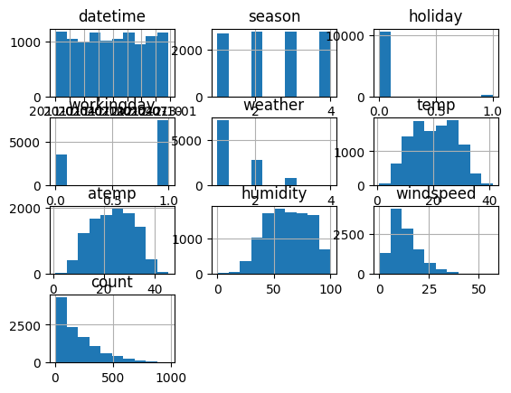

```python
# Create a histogram of all features to show the distribution of each one relative to the data. This is part of the exploritory data analysis
train.hist();
```

```python
# create a new feature
train['hour'] = train['datetime'].dt.hour
test['hour'] = test['datetime'].dt.hour
```

## Make category types for these so models know they are not just numbers

- AutoGluon originally sees these as ints, but in reality they are int representations of a category.
- Setting the dtype to category will classify these as categories in AutoGluon.

```python
train["season"] = train["season"].astype('category')
train["weather"] = train["weather"].astype('category')
test["season"] = test["season"].astype('category')
test["weather"] = test["weather"].astype('category')
```

```python
# View are new feature
train.head()
```

|  | datetime | season | holiday | workingday | weather | temp | atemp | humidity | windspeed | count | hour |
| --- | --- | --- | --- | --- | --- | --- | --- | --- | --- | --- | --- |
| 0 | 2011-01-01 00:00:00 | 1 | 0 | 0 | 1 | 9.84 | 14.395 | 81 | 0.0 | 16 | 0 |
| 1 | 2011-01-01 01:00:00 | 1 | 0 | 0 | 1 | 9.02 | 13.635 | 80 | 0.0 | 40 | 1 |
| 2 | 2011-01-01 02:00:00 | 1 | 0 | 0 | 1 | 9.02 | 13.635 | 80 | 0.0 | 32 | 2 |
| 3 | 2011-01-01 03:00:00 | 1 | 0 | 0 | 1 | 9.84 | 14.395 | 75 | 0.0 | 13 | 3 |
| 4 | 2011-01-01 04:00:00 | 1 | 0 | 0 | 1 | 9.84 | 14.395 | 75 | 0.0 | 1 | 4 |

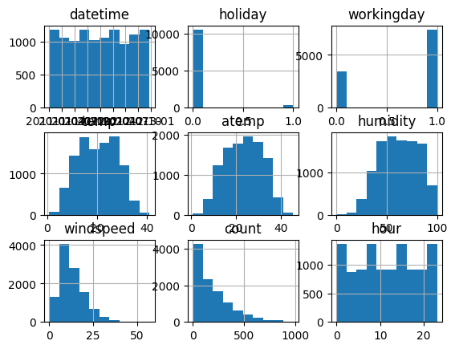

```python
# View histogram of all features again now with the hour feature
train.hist();
```

## Step 5: Rerun the model with the same settings as before, just with more features

```python
predictor_new_features = TabularPredictor(label='count', eval_metric='root_mean_squared_error').fit(train_data=train, presets='best_quality', time_limit=600)
```

[output not shown]

[output cut: 181 more lines]

```
	-30.2833	 = Validation score   (-root_mean_squared_error)
	2.76s	 = Training   runtime
	0.78s	 = Validation runtime
Fitting model: NeuralNetFastAI_r191_BAG_L2 ... Training model for up to 18.63s of the 18.57s of remaining time.
	Fitting 8 child models (S1F1 - S1F8) | Fitting with ParallelLocalFoldFittingStrategy (8 workers, per: cpus=1, gpus=0, memory=0.11%)
	-28.6021	 = Validation score   (-root_mean_squared_error)
	16.93s	 = Training   runtime
	0.17s	 = Validation runtime
Fitting model: WeightedEnsemble_L3 ... Training model for up to 360.0s of the 0.31s of remaining time.
	Ensemble Weights: {'NeuralNetFastAI_r191_BAG_L2': 0.434, 'NeuralNetTorch_r79_BAG_L2': 0.421, 'CatBoost_BAG_L2': 0.105, 'LightGBM_BAG_L2': 0.039}
	-28.0643	 = Validation score   (-root_mean_squared_error)
	0.52s	 = Training   runtime
	0.0s	 = Validation runtime
AutoGluon training complete, total runtime = 446.22s ... Best model: "WeightedEnsemble_L3"
TabularPredictor saved. To load, use: predictor = TabularPredictor.load("AutogluonModels/ag-20240403_121617")
```

```python
predictor_new_features.fit_summary()
```

```
*** Summary of fit() ***
Estimated performance of each model:
                          model   score_val              eval_metric  pred_time_val    fit_time  pred_time_val_marginal  fit_time_marginal  stack_level  can_infer  fit_order
0           WeightedEnsemble_L3  -28.064324  root_mean_squared_error      33.009789  355.161665                0.001791           0.519174            3       True         32
1   NeuralNetFastAI_r191_BAG_L2  -28.602112  root_mean_squared_error      32.667850  293.194365                0.167582          16.934454            2       True         31
2     NeuralNetTorch_r79_BAG_L2  -28.813919  root_mean_squared_error      32.602842  304.639071                0.102574          28.379160            2       True         29
3        NeuralNetFastAI_BAG_L2  -29.274343  root_mean_squared_error      32.583927  282.818336                0.083658           6.558425            2       True         24
4               CatBoost_BAG_L2  -29.936170  root_mean_squared_error      32.526471  307.708175                0.026203          31.448264            2       True         22
5          CatBoost_r177_BAG_L2  -30.167669  root_mean_squared_error      32.523594  293.343458                0.023325          17.083547            2       True         28
6               LightGBM_BAG_L2  -30.209372  root_mean_squared_error      32.711639  277.880613                0.211370           1.620702            2       True         20
7          LightGBM_r131_BAG_L2  -30.283315  root_mean_squared_error      33.285001  279.016140                0.784733           2.756229            2       True         30
8                XGBoost_BAG_L2  -30.542245  root_mean_squared_error      32.556459  277.900811                0.056190           1.640900            2       True         25
9             LightGBMXT_BAG_L2  -30.659078  root_mean_squared_error      32.878112  278.290553                0.377844           2.030642            2       True         19
10         LightGBMLarge_BAG_L2  -30.818999  root_mean_squared_error      32.787462  279.025423                0.287194           2.765512            2       True         27
11       RandomForestMSE_BAG_L2  -31.182012  root_mean_squared_error      32.793277  283.313842                0.293009           7.053931            2       True         21
12         ExtraTreesMSE_BAG_L2  -31.210653  root_mean_squared_error      32.790770  277.609003                0.290502           1.349092            2       True         23
13          WeightedEnsemble_L2  -31.258497  root_mean_squared_error       8.915854  128.058696                0.000217           0.385932            2       True         18
14        NeuralNetTorch_BAG_L2  -31.287055  root_mean_squared_error      32.624029  288.961881                0.123761          12.701970            2       True         26
15           CatBoost_r9_BAG_L1  -32.761607  root_mean_squared_error       0.341416   35.663921                0.341416          35.663921            1       True         16
16         CatBoost_r177_BAG_L1  -33.021127  root_mean_squared_error       0.043586   43.102523                0.043586          43.102523            1       True         12
17              CatBoost_BAG_L1  -33.147130  root_mean_squared_error       0.099476   79.408425                0.099476          79.408425            1       True          6
18         LightGBM_r131_BAG_L1  -33.162237  root_mean_squared_error       9.911983    6.661160                9.911983           6.661160            1       True         14
19         LightGBMLarge_BAG_L1  -33.593758  root_mean_squared_error       1.473004    3.946905                1.473004           3.946905            1       True         11
20              LightGBM_BAG_L1  -33.919639  root_mean_squared_error       1.052589    2.648963                1.052589           2.648963            1       True          4
21            LightGBMXT_BAG_L1  -34.457274  root_mean_squared_error       5.419398    5.067422                5.419398           5.067422            1       True          3
22               XGBoost_BAG_L1  -34.603186  root_mean_squared_error       0.534015    3.150776                0.534015           3.150776            1       True          9
23          LightGBM_r96_BAG_L1  -38.080169  root_mean_squared_error      12.797585    5.651804               12.797585           5.651804            1       True         17
24        NeuralNetTorch_BAG_L1  -38.208857  root_mean_squared_error       0.035186   34.083439                0.035186          34.083439            1       True         10
25         ExtraTreesMSE_BAG_L1  -38.317568  root_mean_squared_error       0.242018    0.684624                0.242018           0.684624            1       True          7
26       RandomForestMSE_BAG_L1  -38.454216  root_mean_squared_error       0.247742    1.531340                0.247742           1.531340            1       True          5
27  NeuralNetFastAI_r191_BAG_L1  -42.098412  root_mean_squared_error       0.134751   16.535588                0.134751          16.535588            1       True         15
28       NeuralNetFastAI_BAG_L1  -45.306915  root_mean_squared_error       0.084299    6.338082                0.084299           6.338082            1       True          8
```

[output cut: 16 more lines]

[output not shown]

[output cut: 343 more lines]

```
 17            1       True          6
 18            1       True         14
 19            1       True         11
 20            1       True          4
 21            1       True          3
 22            1       True          9
 23            1       True         17
 24            1       True         10
 25            1       True          7
 26            1       True          5
 27            1       True         15
 28            1       True          8
 29            1       True         13
 30            1       True          2
 31            1       True          1  }
```

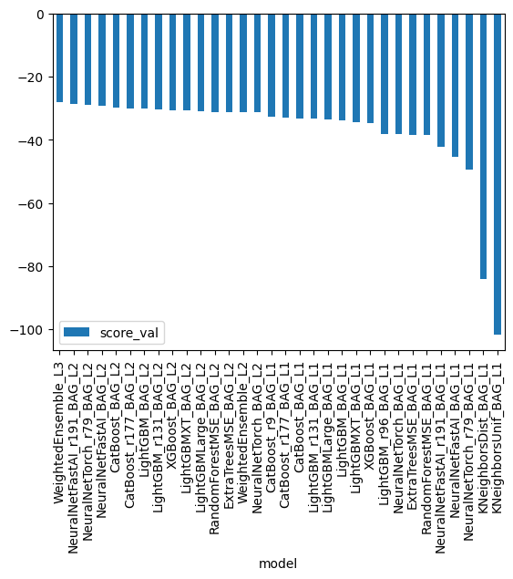

```python
predictor_new_features.leaderboard(silent=True).plot(kind="bar", x="model", y="score_val");
```

```python
# Remember to set all negative values to zero
submission_new_features = submission.copy()
new_predictions = predictor_new_features.predict(test)
new_predictions.head()
```

```
0    15.856874
1     7.133899
2     6.315672
3     7.697198
4     7.443280
Name: count, dtype: float32
```

```python
# How many negative values do we have?
sum(new_predictions<0)
```

```
0
```

```python
# Same submitting predictions
submission_new_features["count"] = new_predictions
submission_new_features.to_csv("submission_new_features.csv", index=False)
```

```python
!kaggle competitions submit -c bike-sharing-demand -f submission_new_features.csv -m "new features"
```

```
Successfully submitted to Bike Sharing Demand
```

```python
!kaggle competitions submissions -c bike-sharing-demand | tail -n +1 | head -n 6
```

[output not shown]

```python
0.83227
```

```
0.83227
```

## Step 6: Hyper parameter optimization

- There are many options for hyper parameter optimization.
- Options are to change the AutoGluon higher level parameters or the individual model hyperparameters.
- The hyperparameters of the models themselves that are in AutoGluon. Those need the `hyperparameter` and `hyperparameter_tune_kwargs` arguments.

### Changing higher level parameters: num_bag_folds, num_bag_sets, num_stack_levels

from documentation:

- num_bag_folds; between 5 and 10
- num_bag_sets; between 1 and 20
- num_stack_levels; between 0 and 3

```python
predictor_new_hpo = TabularPredictor(label='count', eval_metric='root_mean_squared_error').fit(train, presets='best_quality', num_bag_folds=9, num_bag_sets=15, num_stack_levels=3, time_limit=600)
```

[output not shown]

[output cut: 288 more lines]

```
	1.92s	 = Training   runtime
	0.14s	 = Validation runtime
Fitting model: CatBoost_r177_BAG_L4 ... Training model for up to 7.02s of the 6.97s of remaining time.
	Fitting 9 child models (S1F1 - S1F9) | Fitting with ParallelLocalFoldFittingStrategy (9 workers, per: cpus=1, gpus=0, memory=0.12%)
	-28.9278	 = Validation score   (-root_mean_squared_error)
	3.07s	 = Training   runtime
	0.02s	 = Validation runtime
Completed 1/15 k-fold bagging repeats ...
Fitting model: WeightedEnsemble_L5 ... Training model for up to 360.0s of the 2.56s of remaining time.
	Ensemble Weights: {'NeuralNetFastAI_r191_BAG_L2': 0.404, 'NeuralNetTorch_r79_BAG_L2': 0.333, 'RandomForestMSE_BAG_L3': 0.091, 'XGBoost_BAG_L2': 0.061, 'XGBoost_BAG_L3': 0.061, 'NeuralNetFastAI_BAG_L2': 0.02, 'XGBoost_BAG_L4': 0.02, 'NeuralNetFastAI_r191_BAG_L3': 0.01}
	-28.1305	 = Validation score   (-root_mean_squared_error)
	0.32s	 = Training   runtime
	0.0s	 = Validation runtime
AutoGluon training complete, total runtime = 443.78s ... Best model: "WeightedEnsemble_L5"
TabularPredictor saved. To load, use: predictor = TabularPredictor.load("AutogluonModels/ag-20240403_123138")
```

```python
predictor_new_hpo.fit_summary()
```

```
*** Summary of fit() ***
Estimated performance of each model:
                          model   score_val              eval_metric  pred_time_val    fit_time  pred_time_val_marginal  fit_time_marginal  stack_level  can_infer  fit_order
0           WeightedEnsemble_L5  -28.130505  root_mean_squared_error      13.954638  351.579302                0.000198           0.323923            5       True         53
1           WeightedEnsemble_L3  -28.134097  root_mean_squared_error       9.596147  216.744514                0.000262           0.179305            3       True         27
2           WeightedEnsemble_L4  -28.321616  root_mean_squared_error      12.624505  307.677870                0.001183           0.248779            4       True         42
3   NeuralNetFastAI_r191_BAG_L3  -28.488402  root_mean_squared_error      12.084050  274.017948                0.172034          18.494596            3       True         40
4   NeuralNetFastAI_r191_BAG_L2  -28.664791  root_mean_squared_error       9.217864  157.026292                0.136185          18.838625            2       True         25
5        NeuralNetFastAI_BAG_L3  -28.762217  root_mean_squared_error      12.030343  263.884882                0.118326           8.361530            3       True         33
6               CatBoost_BAG_L4  -28.801089  root_mean_squared_error      13.931787  356.054479                0.024087           6.320733            4       True         46
7               LightGBM_BAG_L3  -28.887148  root_mean_squared_error      11.969886  256.749367                0.057870           1.226015            3       True         29
8          CatBoost_r177_BAG_L4  -28.927763  root_mean_squared_error      13.928994  352.799644                0.021294           3.065898            4       True         52
9     NeuralNetTorch_r79_BAG_L2  -28.964811  root_mean_squared_error       9.174768  164.319889                0.093089          26.132223            2       True         23
10         ExtraTreesMSE_BAG_L3  -28.980906  root_mean_squared_error      12.201015  256.858107                0.288999           1.334755            3       True         32
11       RandomForestMSE_BAG_L3  -28.987090  root_mean_squared_error      12.204042  261.380059                0.292026           5.856707            3       True         30
```

[output cut: 54 more lines]

[output not shown]

[output cut: 599 more lines]

```
 38            2       True         17
 39            2       True         20
 40            2       True         15
 41            2       True         12
 42            1       True          6
 43            1       True         11
 44            1       True          4
 45            1       True          3
 46            1       True          9
 47            1       True          7
 48            1       True          5
 49            1       True         10
 50            1       True          8
 51            1       True          2
 52            1       True          1  }
```

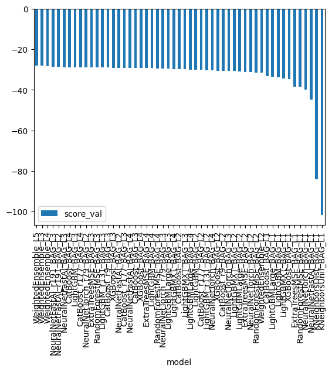

```python
predictor_new_hpo.leaderboard(silent=True).plot(kind="bar", x="model", y="score_val");
```

```python
# Remember to set all negative values to zero
submission_new_hpo = submission.copy()
new_hpo_predictions = predictor_new_hpo.predict(test)
```

```python
# How many negative values do we have?
sum(new_hpo_predictions<0)
```

```
0
```

```python
# Same submitting predictions
submission_new_hpo["count"] = new_hpo_predictions
submission_new_hpo.to_csv("submission_new_hpo.csv", index=False)
```

```python
!kaggle competitions submit -c bike-sharing-demand -f submission_new_hpo.csv -m "new features with hyperparameters"
```

```
Successfully submitted to Bike Sharing Demand
```

```python
!kaggle competitions submissions -c bike-sharing-demand | tail -n +1 | head -n 20
```

```
fileName                     date                 description                        status    publicScore  privateScore
---------------------------  -------------------  ---------------------------------  --------  -----------  ------------
submission_new_hpo.csv       2024-04-03 12:46:48  new features with hyperparameters  complete  0.82871      0.82871
submission_new_hpo.csv       2024-04-02 19:21:38  new features with hyperparameters  complete  0.90089      0.90089
submission_new_hpo.csv       2024-04-02 18:28:37  new features with hyperparameters  complete  0.92376      0.92376
submission_new_hpo.csv       2024-04-02 18:10:30  new features with hyperparameters  complete  0.89085      0.89085
submission_new_hpo.csv       2024-04-02 16:57:32  new features with hyperparameters  complete  0.85264      0.85264
submission_new_hpo.csv       2024-04-02 16:20:05  new features with hyperparameters  complete  0.90274      0.90274
submission_new_hpo.csv       2024-04-02 16:18:49  new features with hyperparameters  complete  0.90144      0.90144
submission_new_hpo.csv       2024-04-02 16:00:42  new features with hyperparameters  complete  0.86922      0.86922
submission_new_hpo.csv       2024-04-02 15:47:48  new features with hyperparameters  complete  0.89464      0.89464
submission_new_features.csv  2024-04-01 16:15:16  new features                       complete  0.83227      0.83227
submission.csv               2024-04-01 15:39:16  first raw submission               complete  1.8371       1.8371
```

```python
0.82871
```

```
0.82871
```

### Changing individual model hyperparameters - XGBoost

https://xgboost.readthedocs.io/en/latest/parameter.html#

- alpha: space.Real(0.0, 2.0, default=0.0)
- lambda: space.Real(1.0, 5.0, default=1.0)
- num_trials = 20
- search_strategy = 'bayes'

```python
from autogluon.common import space

num_trials = 20  # try at most 20 different hyperparameter configurations for each type of model
search_strategy = 'bayes'

xgb_options = {
    'alpha' : space.Real(0.0, 2.0, default=0.0),
    'lambda' : space.Real(1.0, 5.0, default=1.0),
}

hyperparameters = {
                   'XGB': xgb_options,
                  }

hyperparameter_tune_kwargs = {
    'num_trials': num_trials,
    'scheduler' : 'local',
    'searcher': search_strategy,
}
predictor_new_hpo = TabularPredictor(label='count', eval_metric='root_mean_squared_error').fit(train, presets='best_quality', time_limit=600, hyperparameters=hyperparameters, hyperparameter_tune_kwargs=hyperparameter_tune_kwargs)
```

[output not shown]

[output cut: 17 more lines]

```
		('int', ['bool'])            : 2 | ['holiday', 'workingday']
		('int', ['datetime_as_int']) : 5 | ['datetime', 'datetime.year', 'datetime.month', 'datetime.day', 'datetime.dayofweek']
	0.1s = Fit runtime
	10 features in original data used to generate 14 features in processed data.
	Train Data (Processed) Memory Usage: 0.83 MB (0.0% of available memory)
Data preprocessing and feature engineering runtime = 0.07s ...
AutoGluon will gauge predictive performance using evaluation metric: 'root_mean_squared_error'
	This metric's sign has been flipped to adhere to being higher_is_better. The metric score can be multiplied by -1 to get the metric value.
	To change this, specify the eval_metric parameter of Predictor()
User-specified model hyperparameters to be fit:
{
	'XGB': {'alpha': Real: lower=0.0, upper=2.0, 'lambda': Real: lower=1.0, upper=5.0},
}
Fitting 1 L1 models ...
Hyperparameter tuning model: XGBoost_BAG_L1 ... Tuning model for up to 404.94s of the 449.93s of remaining time.
```

[output not shown]

[output cut: 52 more lines]

```
Fitted model: XGBoost_BAG_L1/T19 ...
	-37.1145	 = Validation score   (-root_mean_squared_error)
	12.25s	 = Training   runtime
	0.0s	 = Validation runtime
Fitted model: XGBoost_BAG_L1/T20 ...
	-34.2351	 = Validation score   (-root_mean_squared_error)
	20.15s	 = Training   runtime
	0.0s	 = Validation runtime
Fitting model: WeightedEnsemble_L2 ... Training model for up to 360.0s of the 236.47s of remaining time.
	Ensemble Weights: {'XGBoost_BAG_L1/T8': 0.394, 'XGBoost_BAG_L1/T13': 0.287, 'XGBoost_BAG_L1/T12': 0.223, 'XGBoost_BAG_L1/T11': 0.085, 'XGBoost_BAG_L1/T20': 0.011}
	-33.6402	 = Validation score   (-root_mean_squared_error)
	0.22s	 = Training   runtime
	0.0s	 = Validation runtime
AutoGluon training complete, total runtime = 213.76s ... Best model: "WeightedEnsemble_L2"
TabularPredictor saved. To load, use: predictor = TabularPredictor.load("AutogluonModels/ag-20240403_130559")
```

```python
predictor_new_hpo.fit_summary()
```

```
*** Summary of fit() ***
Estimated performance of each model:
                  model  score_val              eval_metric  pred_time_val   fit_time  pred_time_val_marginal  fit_time_marginal  stack_level  can_infer  fit_order
0   WeightedEnsemble_L2 -33.640177  root_mean_squared_error       0.000445  77.785820                0.000191           0.219248            2       True         21
1    XGBoost_BAG_L1/T13 -34.118496  root_mean_squared_error       0.000048  20.265040                0.000048          20.265040            1       True         13
2     XGBoost_BAG_L1/T8 -34.157142  root_mean_squared_error       0.000053  15.866720                0.000053          15.866720            1       True          8
3    XGBoost_BAG_L1/T20 -34.235112  root_mean_squared_error       0.000054  20.151223                0.000054          20.151223            1       True         20
4    XGBoost_BAG_L1/T11 -34.324514  root_mean_squared_error       0.000053   6.660740                0.000053           6.660740            1       True         11
5    XGBoost_BAG_L1/T12 -34.343878  root_mean_squared_error       0.000047  14.622849                0.000047          14.622849            1       True         12
6     XGBoost_BAG_L1/T1 -34.603186  root_mean_squared_error       0.000097   4.419026                0.000097           4.419026            1       True          1
7    XGBoost_BAG_L1/T16 -34.647951  root_mean_squared_error       0.000051  10.831523                0.000051          10.831523            1       True         16
8     XGBoost_BAG_L1/T4 -34.730728  root_mean_squared_error       0.000046   3.471932                0.000046           3.471932            1       True          4
9     XGBoost_BAG_L1/T7 -34.850314  root_mean_squared_error       0.000052  27.118467                0.000052          27.118467            1       True          7
10   XGBoost_BAG_L1/T18 -34.918577  root_mean_squared_error       0.000046   2.820463                0.000046           2.820463            1       True         18
11   XGBoost_BAG_L1/T15 -35.041693  root_mean_squared_error       0.000062  13.991865                0.000062          13.991865            1       True         15
12    XGBoost_BAG_L1/T2 -35.180523  root_mean_squared_error       0.000061   9.130898                0.000061           9.130898            1       True          2
13    XGBoost_BAG_L1/T6 -35.204447  root_mean_squared_error       0.000053   4.939827                0.000053           4.939827            1       True          6
14    XGBoost_BAG_L1/T3 -35.224772  root_mean_squared_error       0.000052   3.671154                0.000052           3.671154            1       True          3
15   XGBoost_BAG_L1/T17 -36.256023  root_mean_squared_error       0.000051  10.761363                0.000051          10.761363            1       True         17
16   XGBoost_BAG_L1/T10 -36.876290  root_mean_squared_error       0.000053   9.489045                0.000053           9.489045            1       True         10
17   XGBoost_BAG_L1/T19 -37.114512  root_mean_squared_error       0.000052  12.252670                0.000052          12.252670            1       True         19
18   XGBoost_BAG_L1/T14 -38.983758  root_mean_squared_error       0.000052   6.990854                0.000052           6.990854            1       True         14
19    XGBoost_BAG_L1/T5 -39.985121  root_mean_squared_error       0.000049   8.617519                0.000049           8.617519            1       True          5
20    XGBoost_BAG_L1/T9 -41.647391  root_mean_squared_error       0.000054   7.225469                0.000054           7.225469            1       True          9
Number of models trained: 21
Types of models trained:
{'WeightedEnsembleModel', 'StackerEnsembleModel_XGBoost'}
Bagging used: True  (with 8 folds)
Multi-layer stack-ensembling used: False
Feature Metadata (Processed):
(raw dtype, special dtypes):
('category', [])             : 2 | ['season', 'weather']
('float', [])                : 3 | ['temp', 'atemp', 'windspeed']
('int', [])                  : 2 | ['humidity', 'hour']
('int', ['bool'])            : 2 | ['holiday', 'workingday']
('int', ['datetime_as_int']) : 5 | ['datetime', 'datetime.year', 'datetime.month', 'datetime.day', 'datetime.dayofweek']
*** End of fit() summary ***
```

[output not shown]

[output cut: 205 more lines]

```
 6        True          1
 7        True         16
 8        True          4
 9        True          7
 10       True         18
 11       True         15
 12       True          2
 13       True          6
 14       True          3
 15       True         17
 16       True         10
 17       True         19
 18       True         14
 19       True          5
 20       True          9  }
```

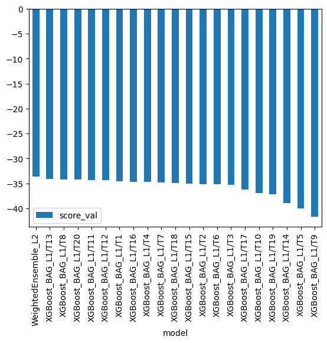

```python
predictor_new_hpo.leaderboard(silent=True).plot(kind="bar", x="model", y="score_val");
```

```python
# Note: Not submitted - root_mean_squared_error score is still high compared to previous models, need more tuning
```

## Step 7: Write a Report

### Refer to the markdown file for the full report

### Creating plots and table for report

```python
import pandas as pd
```

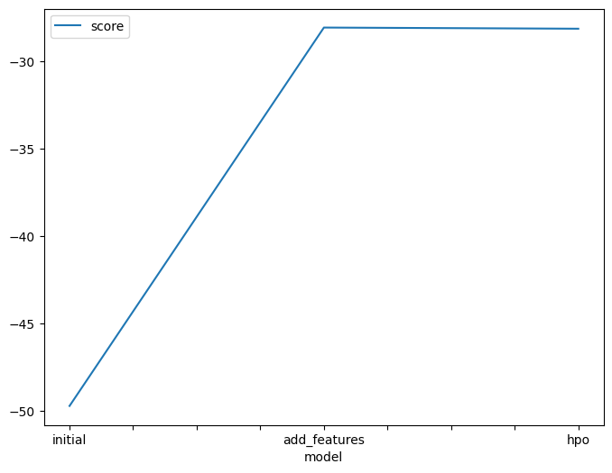

```python
# Taking the top model score from each training run and creating a line plot to show improvement
# You can create these in the notebook and save them to PNG or use some other tool (e.g. google sheets, excel)
fig = pd.DataFrame(
    {
        "model": ["initial", "add_features", "hpo"],
        "score": [-49.706087, -28.064324, -28.130505]
    }
).plot(x="model", y="score", figsize=(8, 6)).get_figure()
fig.savefig('model_train_score.png')
```

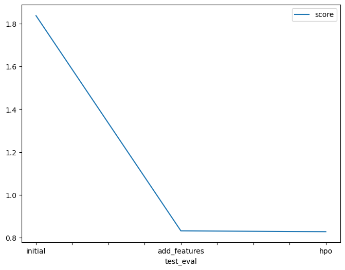

```python
# Take the 3 kaggle scores and creating a line plot to show improvement
fig = pd.DataFrame(
    {
        "test_eval": ["initial", "add_features", "hpo"],
        "score": [1.8371, 0.83227, 0.82871]
    }
).plot(x="test_eval", y="score", figsize=(8, 6)).get_figure()
fig.savefig('model_test_score.png')
```

### Hyperparameter table

```python
# The 3 hyperparameters we tuned with the kaggle score as the result
pd.DataFrame({
    "model": ["initial", "add_features", "hpo"],
    "hpo1": ["Default values", "Default values", "num_bag_folds=9"],
    "hpo2": ["Default values", "Default values", "num_bag_sets=15"],
    "hpo3": ["Default values", "Default values", "num_stack_levels=3"],
    "score": [1.8371, 0.83227, 0.82871]
})
```

|  | model | hpo1 | hpo2 | hpo3 | score |
| --- | --- | --- | --- | --- | --- |
| 0 | initial | Default values | Default values | Default values | 1.83710 |
| 1 | add_features | Default values | Default values | Default values | 0.83227 |
| 2 | hpo | num_bag_folds=9 | num_bag_sets=15 | num_stack_levels=3 | 0.82871 |